# CellCountModeling

```r
library(bestdr)
library(tidyverse)
library(cmdstanr)
library(estipop)
```

# Introduction

We introduce the basic workflow for running a dose response model for counting total cell counts to get the birth and death rates. We will simulate data to provide an example of how data should look for import and running in BESTDR. The resulting model will show how BESTDR can be used to distinguish cytotoxic and cytostatic effects. Second, we will simulate multiple “cell lines” to show how hierarchical modeling can be used to model multiple cell line responses simultaneously.

# Single Cell Line Estimation

## Data Simulation

We will generate parameters from a concentration-response curve for both the birth and death rates. That is, cell will split with rate $b(c)$ and die with rate $d(c)$. The net growth rate is the difference of these two, or $g(c) = b(c) - d(c)$. The concentrations tested are at plotted as points in the figure with the smooth curve representing the smooth function for the birth (blue), death (red), and growth (purple) rates.

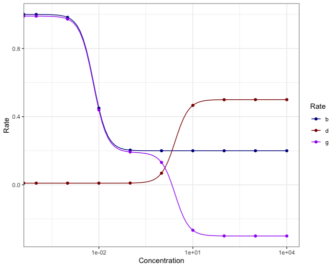

```r
# Generate curve from 4-parameter logistic function for birth and death
b0 <- 1 # left asymptote
bi <- 0.2 # right asymptote
b50 <- -5 # log-dose at midpoint of birthrate (should switch to log scale)
bh <- 2 # Hill Coefficient
db <- b0 - bi # Difference in asymptotes (for parameterization)

d0 <- 0.01
di <- 0.5
d50 <- 1
dh <- 2
dd <- di - d0

b_curve <- function(lc, bi, db, bh, b50) bi + db / (1 + exp(bh * (lc - b50)))
d_curve <- function(lc, d0, dd, dh, d50) d0 + dd - dd / (1 + exp(dh * (lc - d50)))

param_truth <- data.frame(
  bi = bi, b50 = b50, bh = bh, db = db,
  d0 = d0, d50 = d50, dh = dh, dd = dd
)

crange <- c(0, 10^seq(-4, 4, 0.1))
lc_range <- log(crange)
concentrations <- c(0, 10^seq(-4, 4, 1))
log_conc <- log(concentrations)

b_truth <- b_curve(lc_range, bi, db, bh, b50)
d_truth <- d_curve(lc_range, d0, dd, dh, d50)
g_truth <- b_truth - d_truth

curve_truth <- data.frame(concentration = crange,
                          log_conc = lc_range,
                          b = b_truth, d = d_truth, g = g_truth) %>%
  pivot_longer(-c(concentration, log_conc), names_to = "Rate", values_to = "Value")


curve_truth %>%
  ggplot(aes(x = concentration, y = Value, color = Rate)) +
  geom_line() +
  geom_point(data = curve_truth %>% filter(concentration %in% concentrations)) +
  scale_x_log10() +
  labs(x = "Concentration", y = "Rate") +
  scale_color_manual(values = c("darkblue", "darkred", "purple")) +
  theme_bw()
```

We simulate the process using the estipop package. The “rep” variable represents the replicate and the “type1” variable represents the count at a given time.

```r
N <- 10 # Number of samples
tot_time <- 3
dt <- 0.1 # Time between measurements
times <- seq(0, tot_time, dt)
init_pop <- 200 # Number of ancestors

rate_truth <- data.frame(concentration = crange,
                         log_conc = lc_range,
                         b = b_truth, d = d_truth, g = g_truth) %>%
  filter(concentration %in% concentrations)
# Simulate process with estipop
set.seed(9283)
dat <- data.frame()
for (i in seq_along(rate_truth$concentration)) {
  params <- c(rate_truth$b[i], rate_truth$d[i])
  # time-homogeneous two-type model
  model <- estipop::process_model(
    estipop::transition(rate = estipop::rate(params[1]), parent = 1, offspring = 2), # birth
    estipop::transition(rate = estipop::rate(params[2]), parent = 1, offspring = 0) # death
  ) # clearance

  dat_temp <- estipop::branch(model, params, init_pop, times, N, silent = T)
  dat_temp$concentration <- concentrations[i]
  dat_temp$log_conc <- log_conc[i]
  dat <- bind_rows(dat, dat_temp)
}

head(dat)
```

```
#>   rep time type1 concentration log_conc
#> 1   1  0.0   200             0     -Inf
#> 2   1  0.1   220             0     -Inf
#> 3   1  0.2   259             0     -Inf
#> 4   1  0.3   289             0     -Inf
#> 5   1  0.4   314             0     -Inf
#> 6   1  0.5   351             0     -Inf
```

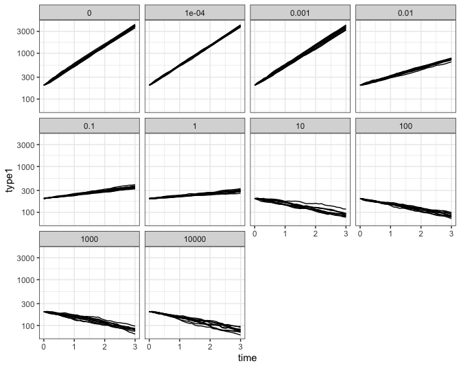

```r
# Plot to look at data
dat %>% ggplot(aes(x = time, group = as.factor(rep))) +
  geom_line(aes(y = type1), col = "black") +
  facet_wrap(concentration ~ .) +
  theme_bw() +
  scale_y_log10()
```

The data needs to be preprocessed before using the model by taking the difference between counts between successive time points.

```r
dat_dt <- dat %>%
  group_by(rep, concentration) %>%
  mutate(
    dt = signif(time - lag(time), 6),
    type1_prev = lag(type1)
) %>% filter(!is.na(dt))
```

## Estimation

We will use a Stan file from the model library to estimate the birth and death rates. We will set up the necessary input data as a list and concatenate the prior distribution parameters for the means and standard deviations for each of the parameters to estimate.

The single type model takes the current and previous count as well as the time between the two counts in separate vectors that are the length of the number of observations (note: observations are not replicates, but the number of time points recorded over all replicates). Each observation has a concentration, convert the concentrations to an index that corresponds to a vector of unique concentrations. The concentration index is used in place of the concentrations for each observation.

That is, if we have concentrations for a set of 5 observations (0.0, 0.1, 0.1, 0.25, 0.0), then the `c_idx` would be (1, 2, 2, 3, 1), `log_conc` would be (0.0, 0.1, 0.25), and `nc` would be 3.

```r
# Estimation with cmdstanr
stanfileloc <- system.file("model_library/1type-livecell/logistic/birthdeath.stan", package = "bestdr")
stanmodel <- cmdstan_model(stanfileloc)

# Set up data for inputs
dat_dt$log_conc_idx <- as.numeric(factor(dat_dt$log_conc, ordered = T))
log_conc <- unique(dat_dt$log_conc)
num_conc <- length(log_conc)

data.list <- list(
  N = nrow(dat_dt),
  count = dat_dt$type1,
  count_prev = dat_dt$type1_prev,
  dt = dat_dt$dt,
  c_idx = dat_dt$log_conc_idx,
  nc = num_conc,
  conc = log_conc
)
prior.list <- list(
  prior_mu_bi = 1,
  prior_s_bi = 0.3,
  prior_mu_db = 0.5,
  prior_s_db = 0.5,
  prior_mu_b50 = 0,
  prior_s_b50 = 1,
  prior_mu_bh = 1,
  prior_s_bh = 0.5,
  prior_mu_d0 = 0.3,
  prior_s_d0 = 0.3,
  prior_mu_dd = 0.5,
  prior_s_dd = 0.5,
  prior_mu_d50 = 0,
  prior_s_d50 = 1,
  prior_mu_dh = 1,
  prior_s_dh = 0.5
)
initfun <- function() {
  list(
    bi = runif(1, 0, 2),
    db = runif(1, 0, 2),
    b50 = runif(1, -2, 2),
    bh = runif(1, 0, 2),
    d0 = runif(1, 0, 2),
    dd = runif(1, 0, 2),
    d50 = runif(1, -2, 2),
    dh = runif(1, 0, 2),
    count_err = runif(data.list$N, -0.5, 0.5)
  )
}
```

For speed, we run the sampler for a single chain for 500 samples

```r
model_posterior <- stanmodel$sample(
  seed = 117,
  data = c(data.list, prior.list),
  chains = 1,
  parallel_chains = 1,
  refresh = 0,
  init = initfun,
  iter_warmup = 1000,
  iter_sampling = 500
)
```

```
#> Running MCMC with 1 chain...
#>
#> Chain 1 finished in 75.2 seconds.
```

```r
model_posterior$summary()
```

```
#> # A tibble: 6,029 × 10
#>    variable       mean   median      sd     mad       q5      q95  rhat ess_bulk
#>    <chr>         <dbl>    <dbl>   <dbl>   <dbl>    <dbl>    <dbl> <dbl>    <dbl>
#>  1 lp__       -1.19e+4 -1.19e+4 4.31e+1 4.03e+1 -1.19e+4 -1.18e+4 1.01      190.
#>  2 bi          2.00e-1  1.99e-1 5.76e-3 5.64e-3  1.91e-1  2.10e-1 1.01      378.
#>  3 db          8.06e-1  8.06e-1 6.83e-3 7.12e-3  7.95e-1  8.17e-1 0.998     356.
#>  4 b50        -5.02e+0 -5.02e+0 3.02e-2 2.92e-2 -5.07e+0 -4.98e+0 1.00      389.
#>  5 bh          1.87e+0  1.86e+0 1.16e-1 1.03e-1  1.70e+0  2.09e+0 1.01      404.
#>  6 d0          1.38e-2  1.34e-2 6.53e-3 7.25e-3  3.00e-3  2.44e-2 1.00      315.
#>  7 dd          4.78e-1  4.78e-1 8.37e-3 8.39e-3  4.65e-1  4.92e-1 0.999     392.
#>  8 d50         1.01e+0  1.01e+0 9.62e-2 1.02e-1  8.50e-1  1.16e+0 0.999     322.
#>  9 dh          1.97e+0  1.96e+0 1.78e-1 1.66e-1  1.72e+0  2.32e+0 0.998     365.
#> 10 count_err…  8.50e-3  1.67e-2 2.86e-1 3.60e-1 -4.40e-1  4.46e-1 1.02      601.
#> # ℹ 6,019 more rows
#> # ℹ 1 more variable: ess_tail <dbl>
```

```r
params_posterior <- model_posterior$draws(variables = c("bi", "db", "b50", "bh", "d0", "dd", "d50", "dh"), format = "df")
```

## Analyzing Results

The following plot shows the posterior samples with the true parameter as a vertical line.

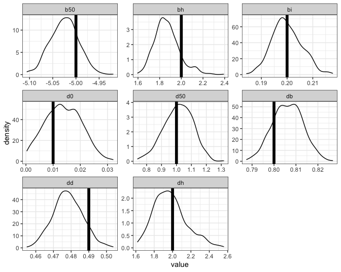

```r
# Compare to ground truth
param_truth_l <- param_truth %>% pivot_longer(everything(), names_to = "stat")

params_posterior_l <- params_posterior %>%
  select(.chain, bi, db, b50, bh, d0, dd, d50, dh) %>%
  pivot_longer(!c(".chain"), names_to = "stat")

# Marginal Posteriors
params_posterior_l %>%
  ggplot(aes(x = value, group = .chain)) +
  geom_density() +
  geom_vline(data = param_truth_l, aes(xintercept = value), linewidth = 2) +
  facet_wrap(. ~ stat, scales = "free") +
  theme_bw()
```

We additionally take posterior samples and create dose-response samples for each to get confidence bands for the dose response curves.

```r
n_posteriors <- 500
crange <- c(10^seq(-6, 4, 0.1))
lcrange <- log(crange)
sample_post <- sample(nrow(params_posterior), n_posteriors, replace = FALSE)
b_post <- data.frame(
  crange,
  sapply(sample_post, function(x) {
    b_curve(
      lcrange,
      params_posterior$bi[x],
      params_posterior$db[x],
      params_posterior$bh[x],
      params_posterior$b50[x]
    )
  })
) %>%
  pivot_longer(cols = !crange, names_to = "sample", values_to = "b")
d_post <- data.frame(
  crange,
  sapply(sample_post, function(x) {
    d_curve(
      lcrange,
      params_posterior$d0[x],
      params_posterior$dd[x],
      params_posterior$dh[x],
      params_posterior$d50[x]
    )
  })
) %>%
  pivot_longer(cols = !crange, names_to = "sample", values_to = "d")
posterior_samples <- b_post %>%
  inner_join(d_post) %>%
  mutate(crange = ifelse(crange == 0, 0.000001, crange),
         g = b - d)
head(posterior_samples)
```

```
#> # A tibble: 6 × 5
#>     crange sample     b       d     g
#>      <dbl> <chr>  <dbl>   <dbl> <dbl>
#> 1 0.000001 X1     1.01  0.0133  0.995
#> 2 0.000001 X2     1.00  0.00761 0.996
#> 3 0.000001 X3     1.01  0.0191  0.993
#> 4 0.000001 X4     0.999 0.00977 0.990
#> 5 0.000001 X5     1.01  0.0179  0.995
#> 6 0.000001 X6     0.997 0.00500 0.992
```

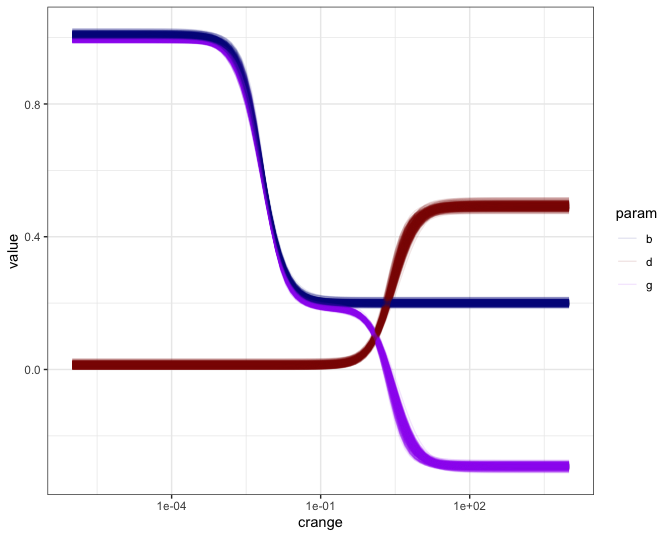

```r
posterior_samples %>% pivot_longer(-c(crange, sample),
                                   names_to = "param", values_to = "value") %>%
  ggplot(aes(x = crange, y = value, color = param, group = interaction(param, sample))) +
  geom_line(alpha = 0.1, linewidth = 0.5) +
  scale_x_log10() +
  scale_color_manual(values = c("darkblue", "darkred", "purple")) +
  theme_bw()
```

The above curves show that the simulation we generated has initial cytostatic effects noted by the decreasing birth rate followed by cytotoxic effects as the concentration increases further which is based on the increasing death rate. We were able to estimate each effect simulataneously.

## Additional metrics

We can further derive additional metrics about the birth, death, or growth curves. For instance, the $b_{50}$ and $d_{50}$ are the concentration at which the birth and death rates reach their midpoint which are parameters of the logistic curve and can provide a measure of how cytotoxic or cytostatic an agent is.

For summary statistics, we can define the $NG_{50}$ and $NG_{0}$ as the concentration where the growth rate hits half it’s initial value and the concentration when the growth rate hits 0 respectively. In the latter case, this is when the cell growth starts decreasing over time.

# Multiple Cell Lines (Hierarchical Model)

## Data Simulation

Using data for a hierarchical model requires an additional group variable to be included. We index this the same way we index concentrations. We’ll illustrate the process for estimating from multiple cell lines by sampling parameters from distributions where we’ve specified the hyperparameters.

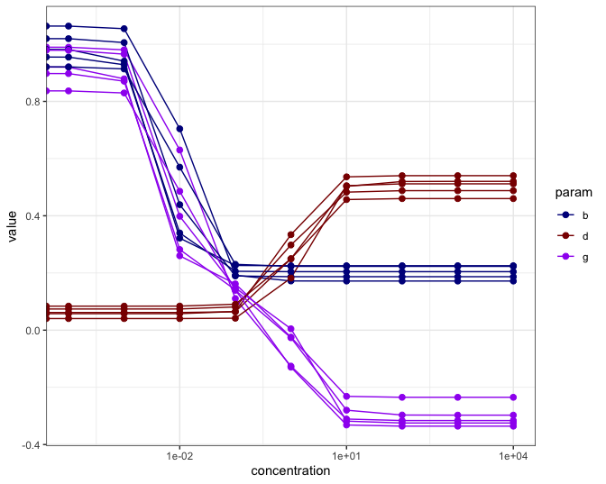

```r
# parameters
set.seed(1238)
b0 <- rnorm(5, 1, 0.05)
bi <- rnorm(5, 0.2, 0.02)
db <- b0 - bi
b50 <- rnorm(5, -5, 0.5)
bh <- rnorm(5, 2, 0.3)
d0 <- rnorm(5, 0.05, 0.02)
di <- rnorm(5, 0.5, 0.1)
dd <- di - d0
d50 <- rnorm(5, 0, 0.2)
dh <- rnorm(5, 2, 0.4)


param_truth <- data.frame(
  group = 1:length(b0),
  bi = bi, db = db, b50 = b50, bh = bh,
  d0 = d0, dd = dd, d50 = d50, dh = dh
)

concentrations <- c(0, 10^seq(-4, 4, 1))
log_conc <- log(concentrations)

b_curve <- function(lc, bi, db, bh, lb50) bi + db / (1 + exp(bh * (lc - lb50)))
d_curve <- function(lc, d0, dd, dh, ld50) d0 + dd - dd / (1 + exp(dh * (lc - ld50)))

b_truth <- data.frame(sapply(1:length(bi), function(i) b_curve(log_conc, bi[i], db[i], bh[i], b50[i])))
d_truth <- data.frame(sapply(1:length(d0), function(i) d_curve(log_conc, d0[i], dd[i], dh[i], d50[i])))
b_truth$concentration <- concentrations
d_truth$concentration <- concentrations
b_truth <- b_truth %>% pivot_longer(!concentration, names_to="group", values_to="b")
d_truth <- d_truth %>% pivot_longer(!concentration, names_to = "group", values_to="d")
curve_truth <- b_truth %>%
  inner_join(d_truth) %>%
  mutate(group = sub("X", "", group),
         g = b - d)

curve_truth %>%
  pivot_longer(-c(concentration, group), names_to = "param", values_to = "value") %>%
  ggplot(aes(x = concentration, y = value, color = param, group = interaction(param, group))) +
    geom_line() +
    geom_point(size = 2) +
  scale_color_manual(values = c("darkblue", "darkred", "purple")) +
  scale_x_log10() +
  theme_bw()
```

Just as before we simulate the data using estipop, but we also loop over the groups / cell lines as well. In this case the `curve_truth` data frame already has 1 row per concentration-group combination.

```r
N <- 5 # Number of samples
tot_time <- 3
dt <- 0.1 # Time between measurements
times <- seq(0, tot_time, dt)
init_pop <- 200 # Number of ancestors


# Simulate process with estipop
set.seed(342)
dat <- data.frame()
for (i in 1:nrow(curve_truth)) {
  params <- c(curve_truth$b[i], curve_truth$d[i])
  # time-homogeneous two-type model
  model <- estipop::process_model(
    estipop::transition(rate = estipop::rate(params[1]), parent = 1, offspring = 2), # birth
    estipop::transition(rate = estipop::rate(params[2]), parent = 1, offspring = 0) # death
  ) # clearance

  dat_temp <- estipop::branch(model, params, init_pop, times, N, silent = T)
  dat_temp$concentration <- curve_truth$concentration[i]
  dat_temp$log_conc <- log(dat_temp$concentration)
  dat_temp$group <- curve_truth$group[i]
  dat <- bind_rows(dat, dat_temp)
}
head(dat)
```

```
#>   rep time type1 concentration log_conc group
#> 1   1  0.0   200             0     -Inf     1
#> 2   1  0.1   216             0     -Inf     1
#> 3   1  0.2   233             0     -Inf     1
#> 4   1  0.3   261             0     -Inf     1
#> 5   1  0.4   282             0     -Inf     1
#> 6   1  0.5   310             0     -Inf     1
```

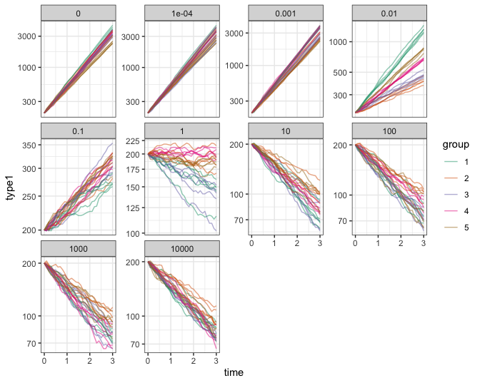

```r
dat %>% ggplot(aes(x = time, group = interaction(group, as.factor(rep)))) +
  geom_line(aes(y = type1, color = group), alpha = 0.5) +
  facet_wrap(concentration ~ ., scales = "free_y") +
  scale_y_log10() +
  scale_color_manual(values = c("#1b9e77", "#d95f02", "#7570b3", "#e7298a", "#a6761d")) +
  theme_bw()
```

```r
# Preprocessing
dat_dr <- dat %>%
  group_by(rep, concentration, group) %>%
  mutate(
    dt = signif(time - lag(time), 6),
    type1_prev = lag(type1)
  ) %>%
  filter(!is.na(dt))

# Set up the data for input into Stan
dat_dr$log_conc_idx <- as.numeric(factor(dat_dr$log_conc, ordered = T))
log_conc <- unique(dat$log_conc)
num_conc <- length(log_conc)
num_groups <- length(unique(dat$group))
```

## Estimation

```r
# Estimation with cmdstanr
stanfileloc <- system.file("model_library/1type-livecell/logistic/birthdeath_mixedeffects.stan",
                           package = "bestdr")
stanmodel <- cmdstan_model(stanfileloc)

data.list <- list(
  N = nrow(dat_dr),
  count = dat_dr$type1,
  count_prev = dat_dr$type1_prev,
  dt = dat_dr$dt,
  c_idx = dat_dr$log_conc_idx,
  nc = num_conc,
  conc = log_conc,
  g_idx = as.numeric(as.factor(dat_dr$group)),
  ng = num_groups
)
prior.list <- list(theta_1_mu_bi = 1.0,
                   theta_2_mu_bi = 0.4,
                   theta_1_s_bi = 0.5,
                   theta_2_s_bi = 0.2,
                   theta_1_mu_db = 1.0,
                   theta_2_mu_db = 0.4,
                   theta_1_s_db = 0.5,
                   theta_2_s_db = 0.2,
                   theta_1_mu_b50 = 0.0,
                   theta_2_mu_b50 = 0.5,
                   theta_1_s_b50 = 0.5,
                   theta_2_s_b50 = 0.2,
                   theta_1_mu_bh = 1.0,
                   theta_2_mu_bh = 0.5,
                   theta_1_s_bh = 0.5,
                   theta_2_s_bh = 0.2,
                   theta_1_mu_d0 = 0.1,
                   theta_2_mu_d0 = 0.4,
                   theta_1_s_d0 = 0.5,
                   theta_2_s_d0 = 0.2,
                   theta_1_mu_dd = 1.0,
                   theta_2_mu_dd = 0.4,
                   theta_1_s_dd = 0.5,
                   theta_2_s_dd = 0.2,
                   theta_1_mu_d50 = 0.0,
                   theta_2_mu_d50 = 0.5,
                   theta_1_s_d50 = 0.5,
                   theta_2_s_d50 = 0.2,
                   theta_1_mu_dh = 1.0,
                   theta_2_mu_dh = 0.5,
                   theta_1_s_dh = 0.5,
                   theta_2_s_dh = 0.2)
initfun = function() {
  list(
    bi = runif(num_groups, 0.1, 2),
    db = runif(num_groups, 0.1, 2),
    b50 = runif(num_groups, -2, 2),
    bh = runif(num_groups, 0.1, 2),
    d0 = runif(num_groups, 0.1, 2),
    dd = runif(num_groups, 0.1, 2),
    d50 = runif(num_groups, -2, 2),
    dh = runif(num_groups, 0.1, 2),
    count_err = runif(data.list$N, -0.5, 0.5)
  )
}

# Sampling
model_posterior <- stanmodel$sample(
  seed=711,
  data = c(data.list, prior.list),
  chains = 1,
  parallel_chains = 1,
  refresh = 0,
  init = initfun,
  iter_warmup = 1000,
  iter_sampling = 500
)
```

```
#> Running MCMC with 1 chain...
#>
#> Chain 1 finished in 223.3 seconds.
```

```r
params_posterior <- model_posterior$draws(
  variables =
    c("bi", "db", "b50", "bh", "d0", "dd", "d50", "dh"), format = "df"
)
hyperparams_posterior <- model_posterior$draws(
  variables =
    c("mu_bi", "mu_db", "mu_b50", "mu_bh", "mu_d0", "mu_dd", "mu_d50", "mu_dh",
      "s_bi", "s_db", "s_b50", "s_bh", "s_d0", "s_dd", "s_d50", "s_dh"), format = "df"
)

params_posterior_l <- params_posterior %>%
  select(.chain, .draw, starts_with("b"), starts_with("d")) %>%
  pivot_longer(!c(".chain", ".draw"), names_to = "stat") %>%
  separate(stat, sep = "\\[", c("stat", "group")) %>%
  mutate(group = (sub("\\]", "", group)))

params_posterior_l %>% group_by(stat, group) %>%
  summarize(value = mean(value)) %>%
  pivot_wider(names_from = "stat", values_from = "value")
```

```
#> # A tibble: 5 × 9
#>   group   b50    bh    bi     d0     d50    db    dd    dh
#>   <chr> <dbl> <dbl> <dbl>  <dbl>   <dbl> <dbl> <dbl> <dbl>
#> 1 1     -4.41  1.93 0.183 0.0698 -0.0878 0.878 0.437  1.46
#> 2 2     -5.58  2.13 0.207 0.0499  0.150  0.769 0.393  1.59
#> 3 3     -5.37  2.06 0.215 0.0564 -0.204  0.743 0.487  1.76
#> 4 4     -5.02  1.92 0.193 0.0485  0.428  0.838 0.456  1.86
#> 5 5     -4.63  1.94 0.216 0.0570  0.265  0.669 0.454  1.44
```

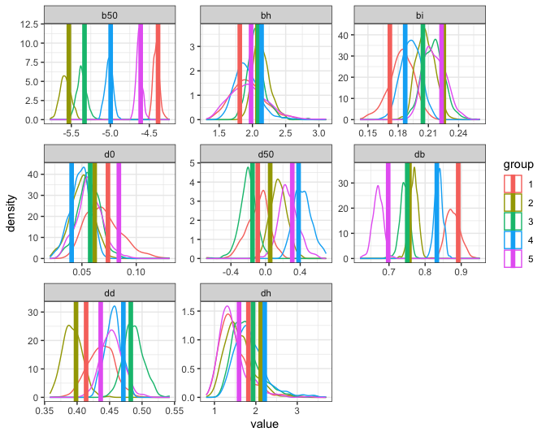

```r
ground_truth_l <- param_truth %>%
  pivot_longer(!group, names_to = "stat") %>%
  mutate(group = as.character(group))
params_posterior_l %>%
  ggplot(aes(x = value, color = group, group = interaction(group, .chain))) +
  geom_density() +
  geom_vline(data = ground_truth_l, aes(xintercept = value, color = group), linewidth = 2) +
  facet_wrap(stat ~ ., scales = "free") +
  theme_bw()
```

Finally, we plot the curves for concentration response posterior samples from each of the 5 groups individually.

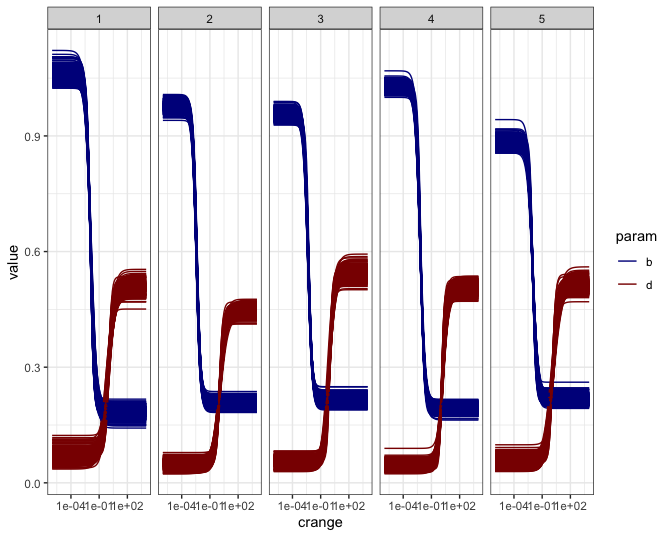

```r
# Samples of posterior curves
n_posteriors <- 300
crange <- c(10^seq(-6, 4, 0.1))
lcrange <- log(crange)
posterior_samples <- data.frame()
for (i in 1:num_groups) {
  sample_post <- sample(nrow(params_posterior), n_posteriors)
  posterior_subset <- params_posterior_l %>%
    filter(group == i, .draw %in% sample_post) %>%
    select(-c(.chain, group)) %>%
    pivot_wider(id_cols = .draw, names_from = "stat")
  b_subset <- data.frame(
    group = i,
    crange,
    sapply(1:n_posteriors, function(x) {
      b_curve(
        lcrange,
        posterior_subset$bi[x],
        posterior_subset$db[x],
        posterior_subset$bh[x],
        posterior_subset$b50[x]
      )
    })
  ) %>%
    pivot_longer(cols = !c(group, crange), names_to = "sample", values_to = "b")
  d_subset <- data.frame(
    group = i,
    crange,
    sapply(1:n_posteriors, function(x) {
      d_curve(
        lcrange,
        posterior_subset$d0[x],
        posterior_subset$dd[x],
        posterior_subset$dh[x],
        posterior_subset$d50[x]
      )
    })
  ) %>%
    pivot_longer(cols = !c(group, crange), names_to = "sample", values_to = "d")
  posterior_samples <- posterior_samples %>%
    bind_rows(b_subset %>%
                inner_join(d_subset) %>%
                mutate(crange = ifelse(crange == 0, 0.000001, crange)))
}


posterior_samples %>%
  pivot_longer(-c(group, crange, sample), names_to = "param", values_to = "value") %>%
  ggplot(aes(x = crange, y = value, color = param, group = interaction(param, sample))) +
  geom_line() +
  facet_grid(.~group) +
  scale_color_manual(values = c("darkblue", "darkred")) +
  scale_x_log10() +
  theme_bw()
```